# Project 2 Decription

Classification

Jyotishka Datta

2021-10-14

# High-dimensional classification

The goal of this project would be to compare a few different classification methods when the number of variables $p$ is large, in either a large $p$, small $n$ setting or when $p$ is of the order of several hundreds or thousands where the problem of selecting a subset of variables is an important one.

The methods that you can consider are logistic regression (with or without penalty depending on your situation), k-nearest neighbour, support vector machine and random forest. We will talk about these methods during the course but for an overview, you can check these pages:

1. [Logistic Demo](http://dattahub.github.io/stat5525/logistic_demo.html)
2. [Decision Tree, Random Forest](http://dattahub.github.io/stat5525/tree_demo.html)
3. [Support Vector Machine](http://dattahub.github.io/stat5525/svm_islr.html)

**Note:** You should submit a 4-page project report (and R codes separately) with descriptions of the methods that you have used and a thorough comparison of the methods used. The report should also mention which member carried out which part of the project.

I will provide a quick example of using `glmnet’ below:

# Penalized Logistic regression

We have seen in class that the estimates from a logistic regression will be unstable in presence of either collinearity or separability, and in the latter case the estimates blow up. It turns out that this is always the case when $p > n$.

For a smaller $p$, the issues might not be as severe but one can still improve the accuracy of prediction and estimation by removing the “noisy” predictors from the data, or equivalently, selecting the significant variables. We show how this works for a logistic regression with an $\ell_1$ penalty.

Logistic regression model:
$$\eta_i = \log(\frac{p_i}{1-p_i}) = \alpha + \sum_{j=1}^{p} x_{ij}\beta_j$$
The log-likelihood is given by:
$$l(y,\beta) = \sum_{i=1}^{n} y_i \log(p_i) +\sum_{i=1}^{n}(1-y_i)\log(1-p_i)$$
We minimize the penalized log-likelihood:
$$S = -l(y,\beta) + \frac{\lambda}{2}J(\beta),$$

where $J(\beta)$ is a penalty function, e.g. $J(\beta) = \lVert \beta \rVert_1$ will lead to an $\ell_1$ penalty that will shrink some of the coefficients all the way to zero to lead to a sparse model. To fit this model to the data, we can use the same R package ‘glmnet’, but we need to change the argument family = “gaussian” to family=“binomial”.

## Measuring performance: Sensitivity and Specificity

- **Sensitivity** (also called the true positive rate) measures the proportion of actual positives which are correctly identified and is complementary to the false negative rate.
- **Specificity** (also called the true negative rate) measures the proportion of negatives which are correctly identified as such and is complementary to the false positive rate.

## HIV Data (Supervised)

PNAS paper studies in vitro drug resistance of $n = 1057$ HIV-1 isolates to protease and reverse transcriptase mutations. There are $p = 208$ (binary) mutation variables.

The original paper compares 5 different regression methods: decision trees, neural networks, SVM regression, OLS and LASSO.

Full paper (if you’re interested): http://www.pnas.org/content/103/46/17355.full

```r
setwd("C:/Users/jyotishka/OneDrive/Documents/Course Notes/stat5525/2021/R codes/datasets")
## save the hiv.rda file somewhere that R can find and use that path
load("hiv.rda")
dim(hiv.train$x)
```

```
## [1] 704 208
```

```r
dim(hiv.test$x)
```

```
## [1] 353 208
```

We have seen how LASSO for regression works on this data-set.

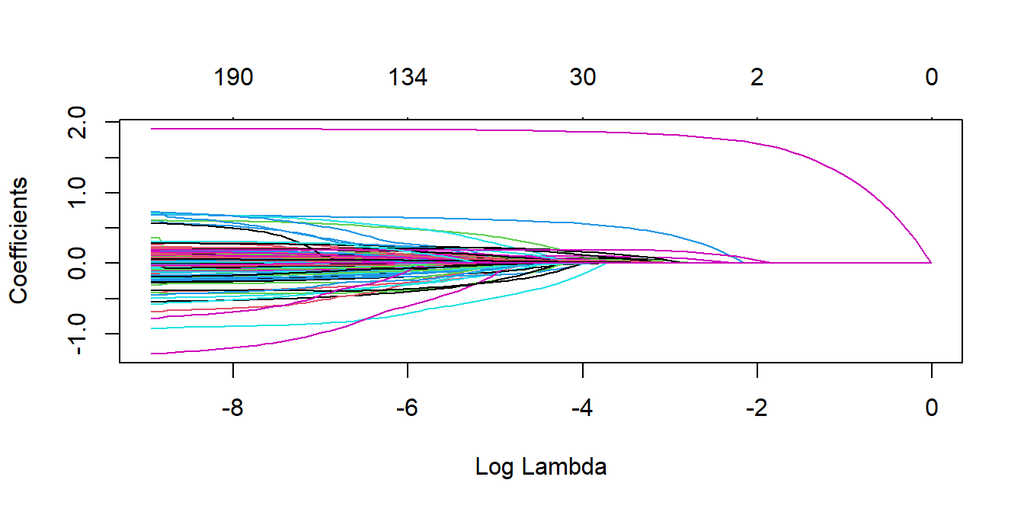

```r
library(glmnet)
set.seed(1)
cvfit <- cv.glmnet(hiv.train$x, hiv.train$y)
fit <- cvfit$glmnet.fit
plot(fit, xvar = "lambda")
```

# Dichotomizing Response

To see how classification works, we will dichotomize the response to create a binary $Y$ variable.

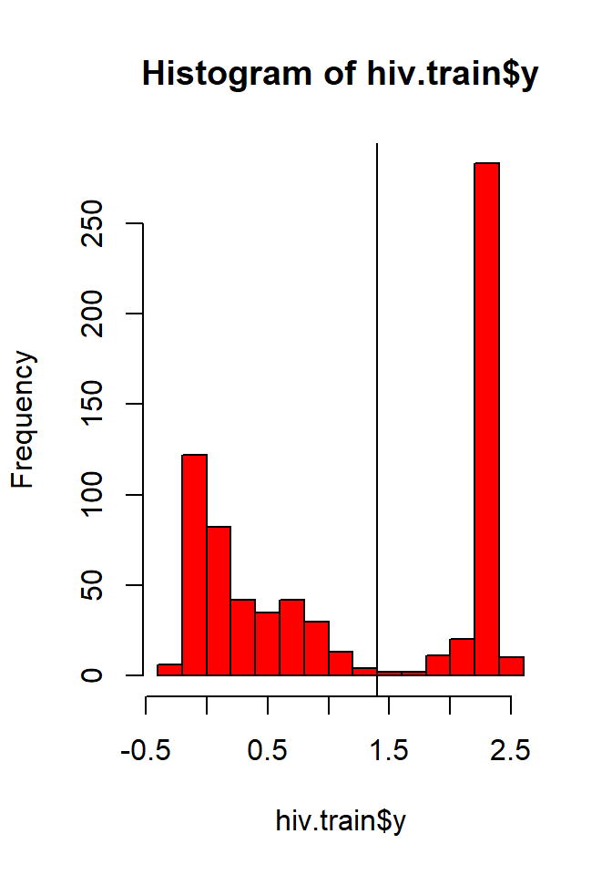

```r
hist(hiv.train$y, col = "red")
abline(v = log(25,10))
```

```r
ytr_b = hiv.train$y > log(25,10)
table(ytr_b)
```

```
## ytr_b
## FALSE  TRUE
##   376   328
```

We’ll treat `ytr_b` as our new response and try a classification algorithm.

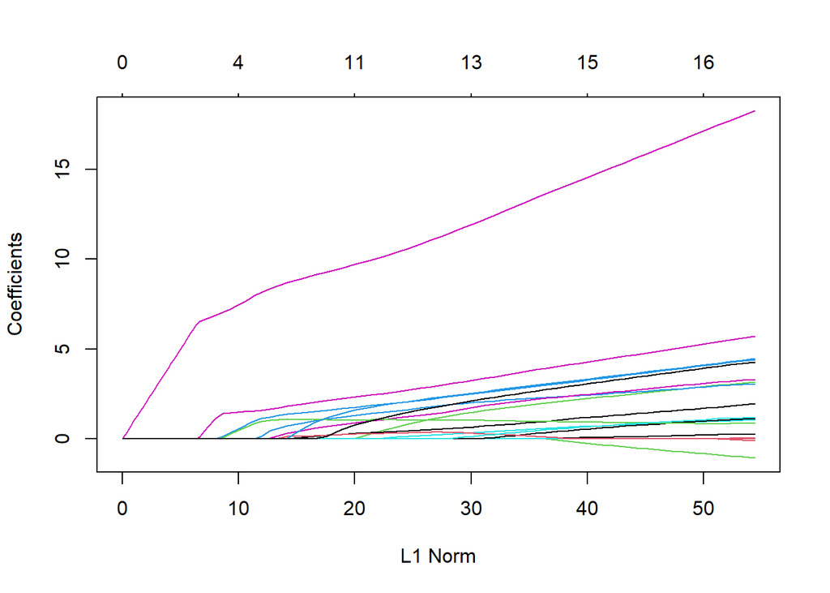

[figure not shown]

```r
# library(glmnet)
fit.bin=glmnet(hiv.train$x,ytr_b, alpha = 1, family = "binomial")
plot(fit.bin)
```

Now, you can find out how many variables were selected by this method, and the MSE in a test data-set. You can compare between different values of $\alpha$, to see if a particular Elastic Net will outperform Lasso, and also compare with the outputs from other methods described before.

The next section decsribes the codes for analyzing the ALL lymphoma data where $p \gg n$, you can also use that data-set if you want. **A simulated data with a large $p$, where the ground truth is known would be fine too**.

## Example from T-cell lymphoma

```r
## required for gene expression data classification example
if (!requireNamespace("BiocManager", quietly = TRUE))
    install.packages("BiocManager")

## Caution: if you're doing this for the first time, it will install *many* packages.
# BiocManager::install(version = "3.12")
# BiocManager::install("ALL", version = "3.12")
library(ALL)
data(ALL)
dim(ALL)
```

```
## Features  Samples
##    12625      128
```

## Simplifying features

We are going to use the first three features.

```r
resp <- gsub("B[0-9]", "B", ALL$BT)
## B-cell tumors of type B, B1,B2, T, T1, T2
resp <- factor(gsub("T[0-9]", "T", resp))
xmat <- t(exprs(ALL))
mydata <- data.frame(y = resp,x1 = xmat[,1],x2=xmat[,2],x3=xmat[,3])
head(mydata,n=3)
```

```
##       y       x1       x2       x3
## 01005 B 7.597323 5.046194 3.900466
## 01010 B 7.479445 4.932537 4.208155
## 03002 B 7.567593 4.799294 3.886169
```

## Penalized logistic regression on ALL data

- We consider the tumor data with $p = 12625$ samples and $n = 128$ individuals. (**Wide Data**)
- We shall fit a $\ell_1$ penalized logistic regression model.
- As we have seen before, this will shrink some of the coefficients to zero.
- Use R-package `glmnet` with `family = “binomial”.

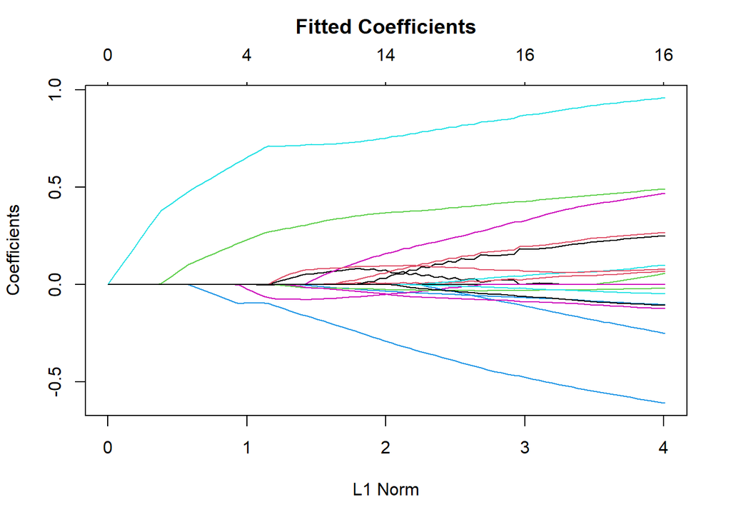

```r
library(glmnet);library(lars)
bcell <- glmnet(x = xmat, y = resp,family = "binomial") # binomial for binary response
plot(bcell)
title("Fitted Coefficients",line=2.5)
```

- We can tell which of the $p = 12625$ features are important and classify $n = 128$ individuals into two groups.

```r
pred.class <- predict(bcell,newx=xmat,s=NULL,type="class")
y.pred <- pred.class[,ncol(pred.class)]
y.obs <- resp
xtabs(~ y.obs +y.pred)
```

```
##      y.pred
## y.obs  B  T
##     B 95  0
##     T  0 33
```

- The classification table shows perfect specificity and sensitivity. Is this surprising?

No, because we are checking classification on training data and zero errors does not mean the method will perform well on test data as well.

# APPENDIX

## Tools used in working with text data

### Description

`grep`, `grepl`, `regexpr`, `gregexpr` and `regexec` search for matches to argument `pattern` within each element of a character vector: they differ in the format of and amount of detail in the results.

`sub` and `gsub` perform replacement of the first and all matches respectively.

### Usage

```
grep(pattern, x, ignore.case = FALSE, perl = FALSE, value = FALSE,
     fixed = FALSE, useBytes = FALSE, invert = FALSE)

grepl(pattern, x, ignore.case = FALSE, perl = FALSE,
      fixed = FALSE, useBytes = FALSE)

sub(pattern, replacement, x, ignore.case = FALSE, perl = FALSE,
    fixed = FALSE, useBytes = FALSE)

gsub(pattern, replacement, x, ignore.case = FALSE, perl = FALSE,
     fixed = FALSE, useBytes = FALSE)

regexpr(pattern, text, ignore.case = FALSE, perl = FALSE,
        fixed = FALSE, useBytes = FALSE)

gregexpr(pattern, text, ignore.case = FALSE, perl = FALSE,
         fixed = FALSE, useBytes = FALSE)

regexec(pattern, text, ignore.case = FALSE, perl = FALSE,
        fixed = FALSE, useBytes = FALSE)
```

### Arguments

[output not shown]

### Details

Arguments which should be character strings or character vectors are coerced to character if possible.

Each of these functions operates in one of three modes:

1. `fixed = TRUE`: use exact matching.
2. `perl = TRUE`: use Perl-style regular expressions.
3. `fixed = FALSE, perl = FALSE`: use POSIX 1003.2 extended regular expressions (the default).

See the help pages on regular expression for details of the different types of regular expressions.

The two `*sub` functions differ only in that `sub` replaces only the first occurrence of a `pattern` whereas `gsub` replaces all occurrences. If `replacement` contains backreferences which are not defined in `pattern` the result is undefined (but most often the backreference is taken to be `""`).

For `regexpr`, `gregexpr` and `regexec` it is an error for `pattern` to be `NA`, otherwise `NA` is permitted and gives an `NA` match.

Both `grep` and `grepl` take missing values in `x` as not matching a non-missing `pattern`.

The main effect of `useBytes = TRUE` is to avoid errors/warnings about invalid inputs and spurious matches in multibyte locales, but for `regexpr` it changes the interpretation of the output. It inhibits the conversion of inputs with marked encodings, and is forced if any input is found which is marked as `“bytes”` (see `Encoding`).

Caseless matching does not make much sense for bytes in a multibyte locale, and you should expect it only to work for ASCII characters if `useBytes = TRUE`.

`regexpr` and `gregexpr` with `perl = TRUE` allow Python-style named captures, but not for *long vector* inputs.

Invalid inputs in the current locale are warned about up to 5 times.

Caseless matching with `perl = TRUE` for non-ASCII characters depends on the PCRE library being compiled with ‘Unicode property support’, which PCRE2 is by default.

### Value

`grep(value = FALSE)` returns a vector of the indices of the elements of `x` that yielded a match (or not, for `invert = TRUE`). This will be an integer vector unless the input is a *long vector*, when it will be a double vector.

`grep(value = TRUE)` returns a character vector containing the selected elements of `x` (after coercion, preserving names but no other attributes).

`grepl` returns a logical vector (match or not for each element of `x`).

`sub` and `gsub` return a character vector of the same length and with the same attributes as `x` (after possible coercion to character). Elements of character vectors `x` which are not substituted will be returned unchanged (including any declared encoding). If `useBytes = FALSE` a non-ASCII substituted result will often be in UTF-8 with a marked encoding (e.g., if there is a UTF-8 input, and in a multibyte locale unless `fixed = TRUE`). Such strings can be re-encoded by `enc2native`.

`regexpr` returns an integer vector of the same length as `text` giving the starting position of the first match or *-1* if there is none, with attribute `“match.length”`, an integer vector giving the length of the matched text (or *-1* for no match). The match positions and lengths are in characters unless `useBytes = TRUE` is used, when they are in bytes (as they are for ASCII-only matching: in either case an attribute `useBytes` with value `TRUE` is set on the result). If named capture is used there are further attributes `“capture.start”`, `“capture.length”` and `“capture.names”`.

`gregexpr` returns a list of the same length as `text` each element of which is of the same form as the return value for `regexpr`, except that the starting positions of every (disjoint) match are given.

`regexec` returns a list of the same length as `text` each element of which is either *-1* if there is no match, or a sequence of integers with the starting positions of the match and all substrings corresponding to parenthesized subexpressions of `pattern`, with attribute `“match.length”` a vector giving the lengths of the matches (or *-1* for no match). The interpretation of positions and length and the attributes follows `regexpr`.

Where matching failed because of resource limits (especially for `perl = TRUE`) this is regarded as a non-match, usually with a warning.

### Performance considerations

If you are doing a lot of regular expression matching, including on very long strings, you will want to consider the options used. Generally `perl = TRUE` will be faster than the default regular expression engine, and `fixed = TRUE` faster still (especially when each pattern is matched only a few times).

If you are working in a single-byte locale and have marked UTF-8 strings that are representable in that locale, convert them first as just one UTF-8 string will force all the matching to be done in Unicode, which attracts a penalty of around *3x* for the default POSIX 1003.2 mode.

If you can make use of `useBytes = TRUE`, the strings will not be checked before matching, and the actual matching will be faster. Often byte-based matching suffices in a UTF-8 locale since byte patterns of one character never match part of another.

PCRE-based matching by default used to put additional effort into ‘studying’ the compiled pattern when `x`/`text` has length 10 or more. That study may use the PCRE JIT compiler on platforms where it is available (see `pcre_config`). As from PCRE2 (PCRE version >= 10.00 as reported by `extSoftVersion`), there is no study phase, but the patterns are optimized automatically when possible, and PCRE JIT is used when enabled. The details are controlled by `options` `PCRE_study` and `PCRE_use_JIT`. (Some timing comparisons can be seen by running file ‘tests/PCRE.R’ in the **R** sources (and perhaps installed).) People working with PCRE and very long strings can adjust the maximum size of the JIT stack by setting environment variable R_PCRE_JIT_STACK_MAXSIZE before JIT is used to a value between `1` and `1000` in MB: the default is `64`. When JIT is not used with PCRE version < 10.30 (that is with PCRE1 and old versions of PCRE2), it might also be wise to set the option `PCRE_limit_recursion`.

### Source

The C code for POSIX-style regular expression matching has changed over the years. As from **R** 2.10.0 (Oct 2009) the TRE library of Ville Laurikari (https://laurikari.net/tre/) is used. The POSIX standard does give some room for interpretation, especially in the handling of invalid regular expressions and the collation of character ranges, so the results will have changed slightly over the years.

For Perl-style matching PCRE2 or PCRE (http://www.pcre.org) is used: again the results may depend (slightly) on the version of PCRE in use.

### References

Becker, R. A., Chambers, J. M. and Wilks, A. R. (1988) *The New S Language*. Wadsworth & Brooks/Cole (`grep`)

### See Also

regular expression (aka `regexp`) for the details of the pattern specification.

`regmatches` for extracting matched substrings based on the results of `regexpr`, `gregexpr` and `regexec`.

`glob2rx` to turn wildcard matches into regular expressions.

`agrep` for approximate matching.

`charmatch`, `pmatch` for partial matching, `match` for matching to whole strings, `startsWith` for matching of initial parts of strings.

`tolower`, `toupper` and `chartr` for character translations.

`apropos` uses regexps and has more examples.

`grepRaw` for matching raw vectors.

Options `PCRE_limit_recursion`, `PCRE_study` and `PCRE_use_JIT`.

`extSoftVersion` for the versions of regex and PCRE libraries in use, `pcre_config` for more details for PCRE.

### Examples

```
grep("[a-z]", letters)

txt <- c("arm","foot","lefroo", "bafoobar")
if(length(i <- grep("foo", txt)))
   cat("'foo' appears at least once in\n\t", txt, "\n")
i # 2 and 4
txt[i]

## Double all 'a' or 'b's;  "\" must be escaped, i.e., 'doubled'
gsub("([ab])", "\\1_\\1_", "abc and ABC")

txt <- c("The", "licenses", "for", "most", "software", "are",
  "designed", "to", "take", "away", "your", "freedom",
  "to", "share", "and", "change", "it.",
  "", "By", "contrast,", "the", "GNU", "General", "Public", "License",
  "is", "intended", "to", "guarantee", "your", "freedom", "to",
  "share", "and", "change", "free", "software", "--",
  "to", "make", "sure", "the", "software", "is",
  "free", "for", "all", "its", "users")
( i <- grep("[gu]", txt) ) # indices
stopifnot( txt[i] == grep("[gu]", txt, value = TRUE) )

## Note that for some implementations character ranges are
## locale-dependent (but not currently).  Then [b-e] in locales such as
## en_US may include B as the collation order is aAbBcCdDe ...
(ot <- sub("[b-e]",".", txt))
txt[ot != gsub("[b-e]",".", txt)]#- gsub does "global" substitution
## In caseless matching, ranges include both cases:
a <- grep("[b-e]", txt, value = TRUE)
b <- grep("[b-e]", txt, ignore.case = TRUE, value = TRUE)
setdiff(b, a)

txt[gsub("g","#", txt) !=
    gsub("g","#", txt, ignore.case = TRUE)] # the "G" words

regexpr("en", txt)

gregexpr("e", txt)

## Using grepl() for filtering
```

[output cut: 55 more lines]

```
URL_parts <- function(x) {
    m <- regexec("^(([^:]+)://)?([^:/]+)(:([0-9]+))?(/.*)", x)
    parts <- do.call(rbind,
                     lapply(regmatches(x, m), `[`, c(3L, 4L, 6L, 7L)))
    colnames(parts) <- c("protocol","host","port","path")
    parts
}
URL_parts(x)

## There is no gregexec() yet, but one can emulate it by running
## regexec() on the regmatches obtained via gregexpr().  E.g.:
pattern <- "([[:alpha:]]+)([[:digit:]]+)"
s <- "Test: A1 BC23 DEF456"
lapply(regmatches(s, gregexpr(pattern, s)),
       function(e) regmatches(e, regexec(pattern, e)))
```